# IODS course project

Elisabet Rams

# Chapter 1. About the project

This course give as a general overview over the possibilities to work with data. No matter the topic, all scientists need to work with lots of data, organize it and analyze it in order to be able to understand it, explain it and represent it. This course will give us the basic tools to do so. Mainly working with R programming language and R-studio software which are probably the most widely used open source tools thanks to its robustness for statistical computing and graphics.

The core values of the course are based on the importance of open data and knowledge sharing.

*Link to GitHub repository:* https://github.com/elirams/IODS-project

# Chapter 2. Regression and model validation

In this chapter we will go through how to read, interpret and represent data. Then we will learn how to apply and interpret simple and multiple regressions. And finally we will go through the most important methods to validate regression models.

### 2.1. Data structure and dimensions

First we will read the data called students2014, explore its structure and dimensions:

```r
learning2014<-read.csv("C:/Users/Elisabet/Desktop/ELI/MASTER'S DEGREE/Open Data Science/GitHub/IODS-project/IODS-project/learning2014.csv", header = TRUE)
```

```r
dim(learning2014)
```

```
## [1] 166   7
```

```r
str(learning2014)
```

```
## 'data.frame':    166 obs. of  7 variables:
##  $ gender  : Factor w/ 2 levels "F","M": 1 2 1 2 2 1 2 1 2 1 ...
##  $ age     : int  53 55 49 53 49 38 50 37 37 42 ...
##  $ attitude: num  3.7 3.1 2.5 3.5 3.7 3.8 3.5 2.9 3.8 2.1 ...
##  $ deep    : num  3.58 2.92 3.5 3.5 3.67 ...
##  $ stra    : num  3.38 2.75 3.62 3.12 3.62 ...
##  $ surf    : num  2.58 3.17 2.25 2.25 2.83 ...
##  $ points  : int  25 12 24 10 22 21 21 31 24 26 ...
```

We can see the our data has 7 variables (columns), and 166 observations. The data is about the different approaches of learning by students. The variables measured are:

**Gender:** It has 2 levels: M for male, F for female

**Age:** age of the students. Integral data type variable.

**Attitude:** global attitude towards statistics.

**Deep:** stands for deep approach learning and it is a combination of variables including: seeking meaning, relating ideas and use of evidence. This variables measure sto what extent the student has the intention to maximize understanding, with a true commitment to learning.

**Stra:** stands for strategic approach and it is a combination of variables including: organized studying and time management. This variables measures to what extent the students organize their studying

**Surf:** stands for surface approach learning and it is a combination of variables including: lack of purpose, unrelated memorising and syllabus-boundness.This variable measures to what extent the student memorizes without understanding, with a serious lack of personal engagement in the learning process.

**Points:** the exam points that students obtained. It is an integral data type. The maximum points that student could get in the exam is 30 plus some extra points from participating in the study, and the minimum points for passing is 12.

The variables attitude, deep, stra and surf are numerical data type with ranging values from 1 to 5. 1 meaning that the student is very far from one specific approach and 5 that the student is very close to that approach.

### 2.2. Data graphical overview and summaries

We will do a graphical overview of the data and show the summaries of the variables, but first we install the packages and bring them to R studio:

```r
library(ggplot2)

library(GGally)
```

```r
summary(learning2014)
```

```
##  gender       age           attitude          deep            stra
##  F:110   Min.   :17.00   Min.   :1.400   Min.   :1.583   Min.   :1.250
##  M: 56   1st Qu.:21.00   1st Qu.:2.600   1st Qu.:3.333   1st Qu.:2.625
##          Median :22.00   Median :3.200   Median :3.667   Median :3.188
##          Mean   :25.51   Mean   :3.143   Mean   :3.680   Mean   :3.121
##          3rd Qu.:27.00   3rd Qu.:3.700   3rd Qu.:4.083   3rd Qu.:3.625
##          Max.   :55.00   Max.   :5.000   Max.   :4.917   Max.   :5.000
##       surf           points
##  Min.   :1.583   Min.   : 7.00
##  1st Qu.:2.417   1st Qu.:19.00
##  Median :2.833   Median :23.00
##  Mean   :2.787   Mean   :22.72
##  3rd Qu.:3.167   3rd Qu.:27.75
##  Max.   :4.333   Max.   :33.00
```

For the graphical overview of the data we will use ggpairs plot from GGally package (which is an extension of the ggplot2), because it is a more advance plot which show us at the same the distribution of the data as well as the relationships between variables. It creates scatter plots and give the correlation value. We specify the combo argument in the lower list because we have both discrete and continuous variables. Mapping describes the aesthetic parameters and in this case we specify to colour male and female.

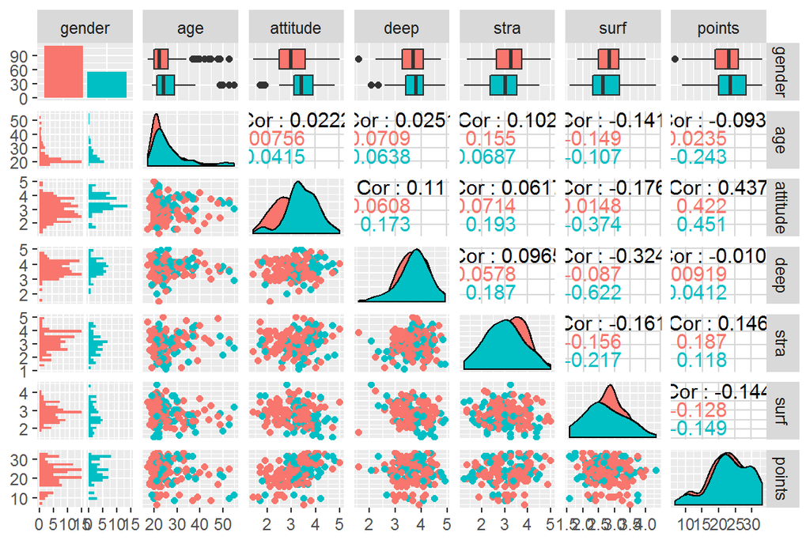

```r
p <- ggpairs(learning2014, mapping = aes(col=gender), lower=list(combo=wrap("facethist", bins=20)))

p
```

With the ggpairs plot we can see graphically the distribution of the variables in the middle diagonal line, sepparated for men (blue) and women (pink). We can also see on the top row a box plot showing the median, first and third quartile for each of the variables. On the left side we have the scatter plots and on the right side the correlations values. We can observe that the variables with clearly higher correlations is attitude with points, with 0.44. Then exam points are also slightly related with strategic and surface approach with 0.15 and 0.14 correlation, respectively.

### 2.3. Regression model:

Now we choose three variables as explanatory variables of the target variable (dependent) which is the exam points. Based on the correlation values, we will choose as explanatory variables: attitude, stra and surf.

First we write the model, since we have more than one variable it is a multiple regression with the formula like y ~ x1 + x2 + x3.

```r
my_model <- lm(points ~ attitude + stra + surf, data=learning2014)
```

Let’s look at the summary of our model:

```r
summary(my_model)
```

```
##
## Call:
## lm(formula = points ~ attitude + stra + surf, data = learning2014)
##
## Residuals:
##      Min       1Q   Median       3Q      Max
## -17.1550  -3.4346   0.5156   3.6401  10.8952
##
## Coefficients:
##             Estimate Std. Error t value Pr(>|t|)
## (Intercept)  11.0171     3.6837   2.991  0.00322 **
## attitude      3.3952     0.5741   5.913 1.93e-08 ***
## stra          0.8531     0.5416   1.575  0.11716
## surf         -0.5861     0.8014  -0.731  0.46563
## ---
## Signif. codes:  0 '***' 0.001 '**' 0.01 '*' 0.05 '.' 0.1 ' ' 1
##
## Residual standard error: 5.296 on 162 degrees of freedom
## Multiple R-squared:  0.2074, Adjusted R-squared:  0.1927
## F-statistic: 14.13 on 3 and 162 DF,  p-value: 3.156e-08
```

On the output we see a table where the first column shows the estimation of each of the coefficients or parameters of the model, then the standard error for these estimations. Finally the T-test value and the p-value to accept or reject the nulle hypothesis. Based on the results, the only variable with p-value close enough to zero to conclude that the nulle hypothesis is false and therefore affirm that there is statistical relationship between variables, is attitude. Therefore stra and surf are not statistically related to points.

We will then rewrite the model including only attitude as the explanatory variable:

```r
my_model2 <- lm(points ~ attitude, data = learning2014)
summary(my_model2)
```

```
##
## Call:
## lm(formula = points ~ attitude, data = learning2014)
##
## Residuals:
##      Min       1Q   Median       3Q      Max
## -16.9763  -3.2119   0.4339   4.1534  10.6645
##
## Coefficients:
##             Estimate Std. Error t value Pr(>|t|)
## (Intercept)  11.6372     1.8303   6.358 1.95e-09 ***
## attitude      3.5255     0.5674   6.214 4.12e-09 ***
## ---
## Signif. codes:  0 '***' 0.001 '**' 0.01 '*' 0.05 '.' 0.1 ' ' 1
##
## Residual standard error: 5.32 on 164 degrees of freedom
## Multiple R-squared:  0.1906, Adjusted R-squared:  0.1856
## F-statistic: 38.61 on 1 and 164 DF,  p-value: 4.119e-09
```

So our final model now looks like this:

y = points X = attitude

$$y = 11.6 + 3.5x$$
$$y = A + Bx$$

A is the point where the regression line intercepts the Y axis and B is the slope of the regression and it shows the relationship between x and y. So in this case when attitude increases one unit, the points increases 3.5 units. Based on what we have previously explained, we can see that there is statistical significance to say that attitude is related to points.

The multiple R squared of the model measure the amount of variation in the target variable that can be explained by the explanatory variables. In this case then, the variable attitude explains 19% of the variation in exam points.

### 2.4. Model validation (diagnostic plots):

The model assumes that the residuals (difference between predicted values and real values) have a constant variance, so that they don’t depend on the explanatory variable. In the following plot we can see how points are really randomly distributed, so that they don’t follow any pattern. For this reason we can say that the assumption is reasonable.

#### Residuals vs Fitted values

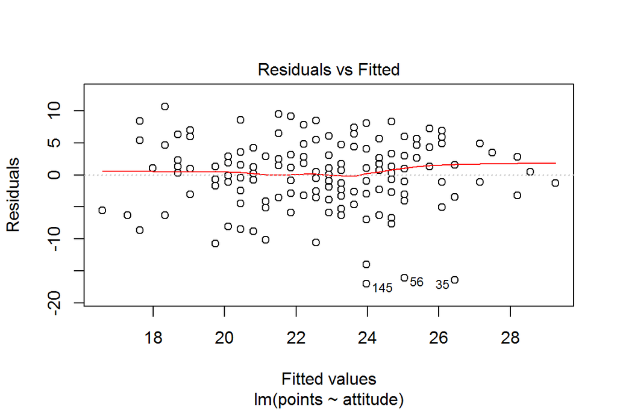

```r
plot(my_model2, which = 1)
```

#### Normal QQ-plot

The model assumes that the residuals are normally distributed. With the following plot we can prove if that assumption is correct. In this case, we can see how the points fall pretty well into the line for almost all values, therefore we can say that the normality assumption is reasonable.

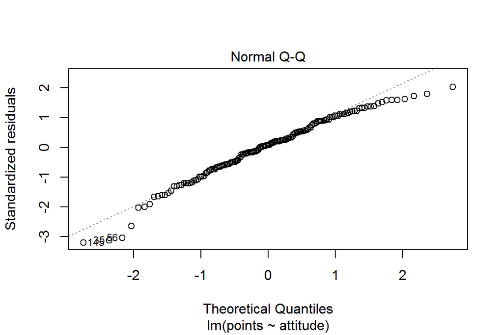

```r
plot(my_model2, which = 2)
```

#### Residuals vs Leverage

Finally, in this plot we can identify if there is single observations which have an unusually high impact in the model. If there exists some single observations which differs so much from the rest, we say that it has high leverage. In this case, we can see how the leverage of the points is similar, there is no single points which have much higher leverage than the others. Therefore, we have regular leverage and that gives more validity to our model.

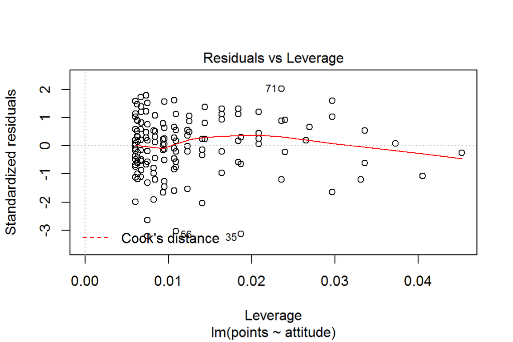

```r
plot(my_model2, which = 5)
```

# Chapter 3. Logistic regression

In this chapter we will analyse the relationships between the target variable, high/low alcohol consumption, and other variables. Because the target variable is discrete (2 values, TRUE or FALSE), we will use logistic regressions in order to do it.

### 3.1. Reading and describing the data

We obtained the original data from the Machine Learning Repository. It is a combination of 2 data sets, student performance in mathematics and in portuguese, from the Student Performance Data Set. It contains 35 variables and 382 observations for each one of them.

We have information about the students and its background, such as sex, age, family size, parents’ education, parents’job, etc.

It also contains information about the students’ grades, the most rellevant is G3 which relates to the final grades.

Because in this exercise we are interested in studying the high consumption of alcohol among students, we created a variable called “alcohol use” (alc_use), which is the average alcohol consumption of the week and the weekend.

Finally we created the variable that we will use as target variable in this exercise, which is “high alcohol consumption”" (high_use). This variable is TRUE for “alcohol use” higher than 2 and FALSE otherwise.

For further information about the variables you can check: https://archive.ics.uci.edu/ml/datasets/Student+Performance

```r
alc <- read.table("C:/Users/Elisabet/Desktop/ELI/MASTER'S DEGREE/Open Data Science/GitHub/IODS-project/IODS-project/alc.csv", header = TRUE, sep = ",")

library(dplyr)
glimpse(alc)
```

```
## Observations: 382
## Variables: 35
## $ school     <fctr> GP, GP, GP, GP, GP, GP, GP, GP, GP, GP, GP, GP, GP...
## $ sex        <fctr> F, F, F, F, F, M, M, F, M, M, F, F, M, M, M, F, F,...
## $ age        <int> 18, 17, 15, 15, 16, 16, 16, 17, 15, 15, 15, 15, 15,...
## $ address    <fctr> U, U, U, U, U, U, U, U, U, U, U, U, U, U, U, U, U,...
## $ famsize    <fctr> GT3, GT3, LE3, GT3, GT3, LE3, LE3, GT3, LE3, GT3, ...
## $ Pstatus    <fctr> A, T, T, T, T, T, T, A, A, T, T, T, T, T, A, T, T,...
## $ Medu       <int> 4, 1, 1, 4, 3, 4, 2, 4, 3, 3, 4, 2, 4, 4, 2, 4, 4, ...
## $ Fedu       <int> 4, 1, 1, 2, 3, 3, 2, 4, 2, 4, 4, 1, 4, 3, 2, 4, 4, ...
## $ Mjob       <fctr> at_home, at_home, at_home, health, other, services...
## $ Fjob       <fctr> teacher, other, other, services, other, other, oth...
## $ reason     <fctr> course, course, other, home, home, reputation, hom...
## $ nursery    <fctr> yes, no, yes, yes, yes, yes, yes, yes, yes, yes, y...
## $ internet   <fctr> no, yes, yes, yes, no, yes, yes, no, yes, yes, yes...
```

[output cut: 22 more lines]

### 3.2 Hypothesis

In order to study the relationships between high alcohol consumption and some other variables, we will choose 4 variables which may have some kind of relationship with the target variable:

*Failures: number of past class failures. Numeric from 0 to 4. Assuming a positive correlation with the target variable. The more alcohol consumption, the more failures.

*Absences: number of school absences. Numeric from 0 to 93. Also assuming positive correlation, higher alcohol consumption, more absences.

*Final Grades: final grade. Numeric from 0 to 20. Assuming a negative correlation, higher alcohol consumption, lower grades.

*Romantic: if the student is in a romantic relationship. Binary, yes or no. Assuming that students in a romantic relationship are more centered in the relationship and so, they do not go out so much to drink with friends.

### 3.3 Describing the distributions of the chosen variables and their relationships with alcohol consumption

#### 3.3.1 Bar plots

First we will look at the distribution of our chosen variables with bar plots.

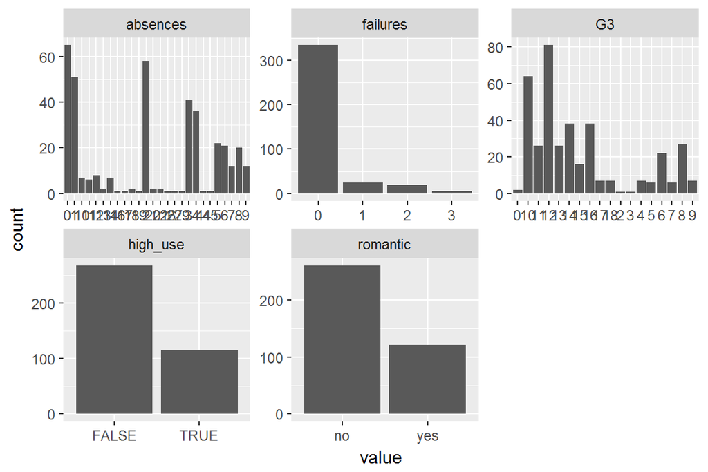

```r
chosen_variables <- subset(alc, select = c("high_use", "failures", "absences", "G3", "romantic"))
library(tidyr)
library(ggplot2)
gather(chosen_variables) %>% ggplot(aes(value)) + facet_wrap("key", scales = "free") + geom_bar()
```

With a barplot of high_use and romantic, we can see that proportionality, students in a romantic relationship have less amount of high alcohol consumption.

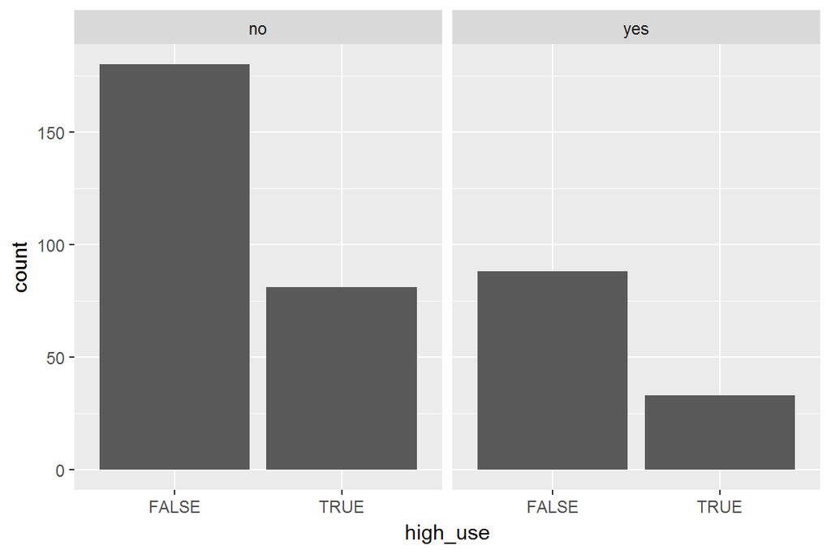

```r
g1 <- ggplot(alc, aes(x = high_use))
g1 + geom_bar() + facet_wrap("romantic")
```

#### 3.3.2 Box plots

Next we will draw some box plots with high_use as the dependent variable and failures, absences, grades and romantic as the dependent ones.

For the first one, with high use vs grades, we also check the differences between males and females.

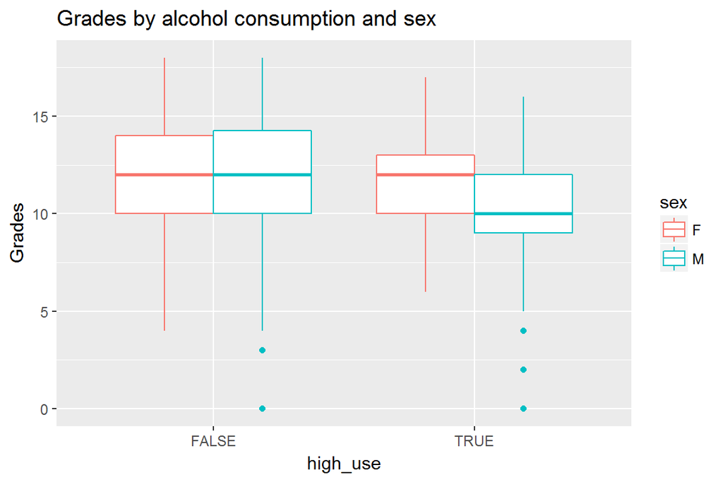

```r
g1 <- ggplot(alc, aes(x= high_use, y = G3, col = sex))
g1 + geom_boxplot() + ylab("Grades") + ggtitle("Grades by alcohol consumption and sex")
```

In the second one we can actually observe that those in a relationship have more absences, but most important, it supports our hypothesis that students with high alcohol consumption have more absences.

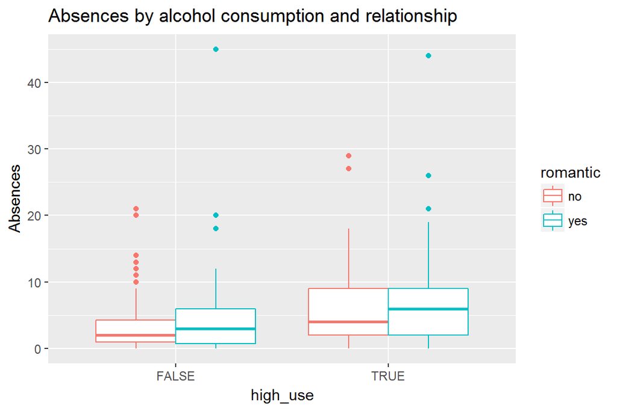

```r
g2 <- ggplot(alc, aes(x= high_use, y = absences, col = romantic))
g2 + geom_boxplot() + ylab("Absences") + ggtitle("Absences by alcohol consumption and relationship")
```

This last graph is quite surprising, seeing that the only significant relationship is with students in a relationship and failures. We don’t see a relationship between failures and high/low alcohol consumption as we hypothesized. Most probably due the fact that failures variable was so skewed to 0 failures.

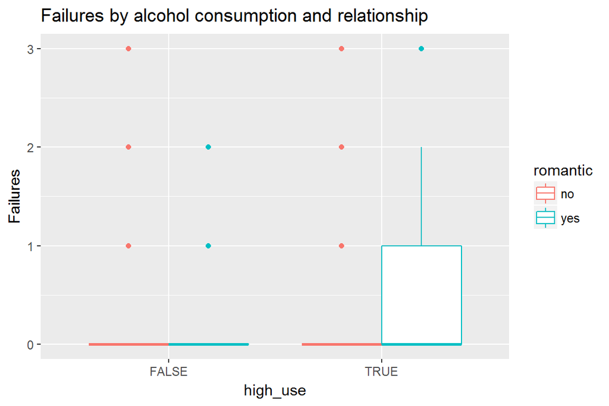

```r
g3 <- ggplot(alc, aes(x= high_use, y = failures, col = romantic))
g3 + geom_boxplot() + ylab("Failures") + ggtitle("Failures by alcohol consumption and relationship")
```

#### 3.3.3 Cross-tabulation

We can also look at the differences nummerically.

First comparing target variable with final grades. We see that students with higher alcohol consumption have lower mean final grades, which supports our hypothesis.

```r
alc %>% group_by (high_use) %>% summarise (count = n(), mean_grade = mean (G3))
```

```
## # A tibble: 2 x 3
##   high_use count mean_grade
##      <lgl> <int>      <dbl>
## 1    FALSE   268   11.73507
## 2     TRUE   114   10.80702
```

We can also count how many of the students in a relationship or not have high/low alcohol consumption. And see the mean grades for each combination. The results support our initial hypothesis and confirm numerically what we could see on the previous graph. Proportionally, students with boyfriend/girlfriend has lower alcohol consumption (**27%** = 33/(33+88)) than those without (**31%** = 81/(180+81)).

Again we can see that students with high alcohol consumption have lower grades. And it is actually funny to see that students in a relationship have also lower grades, but that is not rellevant in our study.

```r
alc %>% group_by (romantic, high_use) %>% summarise (count = n(), mean_grade = mean (G3))
```

```
## # A tibble: 4 x 4
## # Groups:   romantic [?]
##   romantic high_use count mean_grade
##     <fctr>    <lgl> <int>      <dbl>
## 1       no    FALSE   180   12.00556
## 2       no     TRUE    81   11.00000
## 3      yes    FALSE    88   11.18182
## 4      yes     TRUE    33   10.33333
```

In the next table we can see how high alcohol consumption has lower mean grades, higher absences and higher failures.

```r
alc %>% group_by (high_use) %>% summarise (count = n(), mean_grade = mean (G3), mean_absences = mean(absences), mean_failures = mean(failures))
```

```
## # A tibble: 2 x 5
##   high_use count mean_grade mean_absences mean_failures
##      <lgl> <int>      <dbl>         <dbl>         <dbl>
## 1    FALSE   268   11.73507      3.705224     0.1417910
## 2     TRUE   114   10.80702      6.368421     0.3421053
```

If we add to the previous table the romantic variable, we can observe numerically what we have seen on the previous graphs. Students in a romantic relationship have slightly lower grades. Moreover, on the one hand, students with girl/boyfriend have higher absences and failures when they have high alcohol use, but on the other hand , when they have low alcohol use, they have higher absences but lower failures.

```r
alc %>% group_by (high_use, romantic) %>% summarise (count = n(), mean_grade = mean (G3), mean_absences = mean(absences), mean_failures = mean(failures))
```

```
## # A tibble: 4 x 6
## # Groups:   high_use [?]
##   high_use romantic count mean_grade mean_absences mean_failures
##      <lgl>   <fctr> <int>      <dbl>         <dbl>         <dbl>
## 1    FALSE       no   180   12.00556      3.405556     0.1444444
## 2    FALSE      yes    88   11.18182      4.318182     0.1363636
## 3     TRUE       no    81   11.00000      5.777778     0.3086420
## 4     TRUE      yes    33   10.33333      7.818182     0.4242424
```

### 3.4 Logistic regression

After looking at the data and the possible relationships between variables, now we are going to create a model with the chosen variables, and see if the hypothesis we have are actually statistically confirmed or rejected.

So our model would be:

$$high-use = romantic + grades + failures + absences$$

The results of the logistic regression clearly shows that we did not choose the most proper variables, because what the previous exploration of the data suggested is not what we see now after applying the regression model. In our model, the only statistically significant variables are absences and failures, leaving romantic and grades out. Most probably choosing romantic as an explanatory variable biased the whole model. So if required, it would be adequate to perform again the regression with different variables and check if we could obtain a better model to explain high/low alcohol consumption.

```r
m <- glm(high_use ~ romantic + absences + failures + G3, data = alc, family = "binomial")

summary(m)
```

```
##
## Call:
## glm(formula = high_use ~ romantic + absences + failures + G3,
##     family = "binomial", data = alc)
##
## Deviance Residuals:
##     Min       1Q   Median       3Q      Max
## -2.2106  -0.7928  -0.7038   1.1546   1.9020
##
## Coefficients:
##             Estimate Std. Error z value Pr(>|z|)
## (Intercept) -0.67924    0.49112  -1.383 0.166652
## romanticyes -0.34058    0.25850  -1.318 0.187658
## absences     0.08623    0.02282   3.779 0.000157 ***
## failures     0.39863    0.20005   1.993 0.046301 *
## G3          -0.05083    0.03818  -1.332 0.183020
## ---
## Signif. codes:  0 '***' 0.001 '**' 0.01 '*' 0.05 '.' 0.1 ' ' 1
##
## (Dispersion parameter for binomial family taken to be 1)
##
##     Null deviance: 465.68  on 381  degrees of freedom
## Residual deviance: 436.93  on 377  degrees of freedom
## AIC: 446.93
##
## Number of Fisher Scoring iterations: 4
```

#### Odd ratios and confidence intervals

Next we will interpret the coefficients of the model as odd ratios and provide confidence intervals for them.

The odds ratio quantifies the relationship between X and Y. In this case Y is high alcohol use and X are the explanatory variables used in our model: romantic, absences, failures and grades.

For example, if we take the X as romantic, the odds ratio measures the odds of having high alcohol consumption when the student is in a relationship divided the odds of having high alcohol consumption when the students is single.

$$OR = odds (Y | X) / Odds (Y | without X )$$

The computational target variable is in logistic regression, the log of the odds. So if we apply exponential function to the fitted values, we will obtain the odds.

So in the OR that we have computed we can observe that Students in a relationship are only 0.7 as likely to be high alcohol consumers than those without. Or in other words, single students are 1.4 times more likely to be high alcohol consumers (to see the odd ratio for “romanticno”, we just calculate the inverse, so 0.71^-1 = 1.41).

We must interpret the odds ratio for non-binary variables as the ratio of being high alcohol consumer and one unit of change in variable X, divided by the ratio of being high alcohol consumer and no change in variable X:

$$exp(coef) = Odds(Y | X+1)/Odds(Y | X)$$

Therefore, with the odds ratio of absences, we can interpret that a student with one more absence is 1.09 more likely to be high alcohol consumer than the student who don’t have that one more absence. Of course, with failures, the possible values are more limited (only from 0 to 4), so the change is bigger. The student with one more failure is 1.5 times more likely to be high alcohol consumer than the student without that extra failure.

The confidence intervals shows us where are the vast majority of observations. So for the romantic variable, the CI is very wide, that is why we have not found statistical correlation. For both romantic and G3, the CI go from lower than 1 to higher than 1, so it is unclear if the correlation with target variable is postive or negative, so that is another reason that they cannot be significant.

Therefore we confirm our hypothesis that high alcohol consumption is positively related to absences and failures. But reject our hypothesis that high alcohol consumption is related anyhow to romantic relationships and grades.

```r
# To compute OR (odds ratio) and CI (confidence intervals:

OR <- coef(m) %>% exp()
CI <- confint(m) %>% exp()
# Print them out:
cbind(OR, CI)
```

```
##                    OR     2.5 %   97.5 %
## (Intercept) 0.5070040 0.1908492 1.316612
## romanticyes 0.7113585 0.4240480 1.171181
## absences    1.0900618 1.0446648 1.142606
## failures    1.4897812 1.0079375 2.221726
## G3          0.9504370 0.8816401 1.024407
```

### 3.5 Predictions

Now, we will select only the significant variables (based on the previous logistic regression model) and create a new model to explore the predictive power of our model.

First we write the new model, then we predict the probability of high use based on the response of our model. After we add the probabilities and the predictions to our data set. Predictions would be true only when prob > 0.5. Finally we make a cross tabulation.

On the first table we can observe that for high use consumers, there is only 15 where prediction would be true and 99 false, so in 99 of the cases the prediction said it would not be a high alcohol consumer when in fact it is. We can also observe than in 10 of the cases the model predicted the student to be high alcohol consumer when he/she was not. That shows already the weak prediction power of our model.

On the second table we can see it in percentages, only 3.9% of predictions are true for high alcohol use students and 68% of predictions are true for low alcohol use students.

To sum up, our model does the right prediction in 71.4% of the cases which is reasonable but could be improved.

```r
# We write the new model:
m2 <- glm(high_use ~ failures + absences, data = alc, family = "binomial")

summary(m2)
```

```
##
## Call:
## glm(formula = high_use ~ failures + absences, family = "binomial",
##     data = alc)
##
## Deviance Residuals:
##     Min       1Q   Median       3Q      Max
## -2.2680  -0.8019  -0.6967   1.2522   1.7906
##
## Coefficients:
##             Estimate Std. Error z value Pr(>|z|)
## (Intercept) -1.37829    0.16479  -8.364  < 2e-16 ***
## failures     0.49972    0.18456   2.708 0.006776 **
## absences     0.08602    0.02287   3.762 0.000169 ***
## ---
## Signif. codes:  0 '***' 0.001 '**' 0.01 '*' 0.05 '.' 0.1 ' ' 1
##
## (Dispersion parameter for binomial family taken to be 1)
##
##     Null deviance: 465.68  on 381  degrees of freedom
## Residual deviance: 440.14  on 379  degrees of freedom
## AIC: 446.14
##
## Number of Fisher Scoring iterations: 4
```

```r
# We predict the probability of high_use, based on the response of our model:

probabilities <- predict(m2, type = "response")

# We add the probabilities to our data set:

alc <- mutate(alc, probability = probabilities)

# Now we use these probabilities to make a prediction of high use (the prediction will only be true if probability is higher than 0.5):

alc <- mutate(alc, prediction = probability > 0.5)

# Let's tabulate the predictions versus the actual values:

table(high_use = alc$high_use, prediction = alc$prediction)
```

```
##         prediction
## high_use FALSE TRUE
##    FALSE   258   10
##    TRUE     99   15
```

```r
table(high_use = alc$high_use, prediction = alc$prediction) %>% prop.table() %>% addmargins()
```

```
##         prediction
## high_use      FALSE       TRUE        Sum
##    FALSE 0.67539267 0.02617801 0.70157068
##    TRUE  0.25916230 0.03926702 0.29842932
##    Sum   0.93455497 0.06544503 1.00000000
```

We can also draw a plot to see the true values of high_use against the predictions:

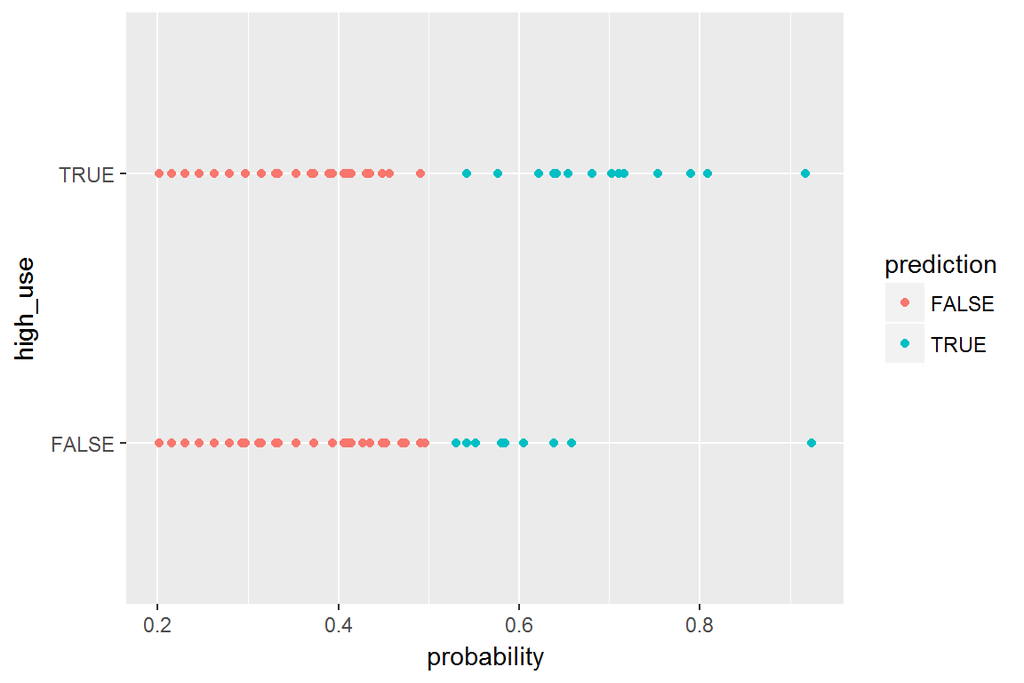

```r
# We can also see it graphically:

g <- ggplot(alc, aes(x=probability, y=high_use, col=prediction))

g + geom_point()
```

Finally, to measure the accuracy of our model, we will compute the total proportion of inaccurately classified individuals (=incorrect predictions in the training data). We will define a loss function for this purpose and then compute the average number of wrong predictions in the training data. We obtained that 0.29 or 29% of predictions are wrong.

The performance of the model is reasonable but one can guess that we could have found a better model for the prediction of high/low alcohol consumers. The simple guessing strategy gave us quite good understanding but still we were wrong for 2 of the 4 variables so, that is questionable.

```r
loss_func <- function(class, prob){
  n_wrong <- abs(class - prob) > 0.5
  mean(n_wrong)
}

loss_func(class=alc$high_use, prob=alc$probability)
```

```
## [1] 0.2853403
```

### 3.6 Cross-validation

As we have seen, statistical models can be used to make predictions . Cross-validation aims to estimate how accurately a predictive model will perform in practice.

In cross-validation, we calculate the same loss function as before, but with different data than the one used for defining the model (=testing data). Or what is the same, we can calculate the average of wrong predictions in the testing data.

```r
# 10-fold cross-validation:
library(boot)
cv <- cv.glm(data=alc, cost=loss_func, glmfit = m2, K=10)

# Average number of wrong prediction in the testing data with a 10-fold cross validation:

cv$delta[1]
```

```
## [1] 0.2853403
```

The average number of wrong predictions in cross validation for my model, is 0.29, which is higher than the error from example model in Datacamp, 0.26. So my model has worse test set performance, as one could have expected at this point of the exercise.

### SUPER BONUS

We can make different logistic regression models and see their performance, looking at the training at testing errors. In the following models (model 3 to model 7) we have started with 6 explanatory variables, and every next model we erase the less significant variable.

Looking at the errors, we cannot see any tendency if either having more or less variables improves the model performance.

**Model 3 (6 predictors):**

```r
# Model 3, 6 predictors:
m3 <- glm(high_use ~ sex + failures + absences + G3 + romantic + goout, data = alc, family = "binomial")

summary(m3)
```

```
##
## Call:
## glm(formula = high_use ~ sex + failures + absences + G3 + romantic +
##     goout, family = "binomial", data = alc)
##
## Deviance Residuals:
##     Min       1Q   Median       3Q      Max
## -2.1319  -0.7948  -0.5292   0.8075   2.4357
##
## Coefficients:
##             Estimate Std. Error z value Pr(>|z|)
## (Intercept) -3.66129    0.72329  -5.062 4.15e-07 ***
## sexM         0.90410    0.25705   3.517 0.000436 ***
## failures     0.29568    0.22493   1.315 0.188669
## absences     0.08370    0.02243   3.732 0.000190 ***
## G3          -0.02973    0.04204  -0.707 0.479487
## romanticyes -0.30928    0.27986  -1.105 0.269103
## goout        0.69962    0.12050   5.806 6.40e-09 ***
## ---
## Signif. codes:  0 '***' 0.001 '**' 0.01 '*' 0.05 '.' 0.1 ' ' 1
##
## (Dispersion parameter for binomial family taken to be 1)
##
##     Null deviance: 465.68  on 381  degrees of freedom
## Residual deviance: 383.45  on 375  degrees of freedom
## AIC: 397.45
##
## Number of Fisher Scoring iterations: 4
```

```r
# Adding probability and prediction columns to our data
probabilities3 <- predict(m3, type = "response")
alc <- mutate(alc, probability3 = probabilities3)
alc <- mutate(alc, prediction3 = probability3 > 0.5)

#Training error m3:
loss_func(class=alc$high_use, prob=alc$probability3)
```

```
## [1] 0.2015707
```

```r
#Testing error m3:
cv <- cv.glm(data=alc, cost=loss_func, glmfit = m3, K=10)
cv$delta[1]
```

```
## [1] 0.2146597
```

**Model 4 (5 predictors):**

```r
# Model 4, 5 predictors:
m4 <- glm(high_use ~ sex + failures + absences + romantic + goout, data = alc, family = "binomial")

summary(m4)
```

```
##
## Call:
## glm(formula = high_use ~ sex + failures + absences + romantic +
##     goout, family = "binomial", data = alc)
##
## Deviance Residuals:
##     Min       1Q   Median       3Q      Max
## -2.0766  -0.7901  -0.5395   0.7706   2.4403
##
## Coefficients:
##             Estimate Std. Error z value Pr(>|z|)
## (Intercept) -4.05277    0.47663  -8.503  < 2e-16 ***
## sexM         0.90227    0.25695   3.511 0.000446 ***
## failures     0.35231    0.21070   1.672 0.094508 .
## absences     0.08466    0.02244   3.773 0.000161 ***
## romanticyes -0.29147    0.27850  -1.047 0.295294
## goout        0.70951    0.11992   5.916 3.29e-09 ***
## ---
## Signif. codes:  0 '***' 0.001 '**' 0.01 '*' 0.05 '.' 0.1 ' ' 1
##
## (Dispersion parameter for binomial family taken to be 1)
##
##     Null deviance: 465.68  on 381  degrees of freedom
## Residual deviance: 383.95  on 376  degrees of freedom
## AIC: 395.95
##
## Number of Fisher Scoring iterations: 4
```

```r
# Adding probability and prediction columns to our data
probabilities4 <- predict(m4, type = "response")
alc <- mutate(alc, probability4 = probabilities4)
alc <- mutate(alc, prediction4 = probability4 > 0.5)

#Training error m4:
loss_func(class=alc$high_use, prob=alc$probability4)
```

```
## [1] 0.2172775
```

```r
#Testing error m4:
cv <- cv.glm(data=alc, cost=loss_func, glmfit = m4, K=10)
cv$delta[1]
```

```
## [1] 0.2225131
```

**Model 5 (4 predictors):**

```r
# Model 5, 4 predictors:
m5 <- glm(high_use ~ sex + failures + absences + goout, data = alc, family = "binomial")

summary(m5)
```

```
##
## Call:
## glm(formula = high_use ~ sex + failures + absences + goout, family = "binomial",
##     data = alc)
##
## Deviance Residuals:
##     Min       1Q   Median       3Q      Max
## -2.0299  -0.7890  -0.5417   0.7857   2.3588
##
## Coefficients:
##             Estimate Std. Error z value Pr(>|z|)
## (Intercept) -4.13390    0.47292  -8.741  < 2e-16 ***
## sexM         0.91999    0.25625   3.590 0.000330 ***
## failures     0.34560    0.21093   1.638 0.101330
## absences     0.08243    0.02235   3.688 0.000226 ***
## goout        0.70797    0.11998   5.901 3.62e-09 ***
## ---
## Signif. codes:  0 '***' 0.001 '**' 0.01 '*' 0.05 '.' 0.1 ' ' 1
##
## (Dispersion parameter for binomial family taken to be 1)
##
##     Null deviance: 465.68  on 381  degrees of freedom
## Residual deviance: 385.06  on 377  degrees of freedom
## AIC: 395.06
##
## Number of Fisher Scoring iterations: 4
```

```r
# Adding probability and prediction columns to our data
probabilities5 <- predict(m5, type = "response")
alc <- mutate(alc, probability5 = probabilities5)
alc <- mutate(alc, prediction5 = probability5 > 0.5)

#Training error m5:
loss_func(class=alc$high_use, prob=alc$probability5)
```

```
## [1] 0.2146597
```

```r
#Testing error m5:
cv <- cv.glm(data=alc, cost=loss_func, glmfit = m5, K=10)
cv$delta[1]
```

```
## [1] 0.2146597
```

**Model 6 (3 predictors):**

```r
# Model 6, 3 predictors:
m6 <- glm(high_use ~ sex + absences + goout, data = alc, family = "binomial")

summary(m6)
```

```
##
## Call:
## glm(formula = high_use ~ sex + absences + goout, family = "binomial",
##     data = alc)
##
## Deviance Residuals:
##     Min       1Q   Median       3Q      Max
## -1.7871  -0.8153  -0.5446   0.8357   2.4740
##
## Coefficients:
##             Estimate Std. Error z value Pr(>|z|)
## (Intercept) -4.16317    0.47506  -8.764  < 2e-16 ***
## sexM         0.95872    0.25459   3.766 0.000166 ***
## absences     0.08418    0.02237   3.764 0.000167 ***
## goout        0.72981    0.11970   6.097 1.08e-09 ***
## ---
## Signif. codes:  0 '***' 0.001 '**' 0.01 '*' 0.05 '.' 0.1 ' ' 1
##
## (Dispersion parameter for binomial family taken to be 1)
##
##     Null deviance: 465.68  on 381  degrees of freedom
## Residual deviance: 387.75  on 378  degrees of freedom
## AIC: 395.75
##
## Number of Fisher Scoring iterations: 4
```

```r
# Adding probability and prediction columns to our data
probabilities6 <- predict(m6, type = "response")
alc <- mutate(alc, probability6 = probabilities6)
alc <- mutate(alc, prediction6 = probability6 > 0.5)

#Training error m6:
loss_func(class=alc$high_use, prob=alc$probability6)
```

```
## [1] 0.2094241
```

```r
#Testing error m6:
cv <- cv.glm(data=alc, cost=loss_func, glmfit = m6, K=10)
cv$delta[1]
```

```
## [1] 0.2172775
```

**Model 7 (2 predictors):**

```r
# Model 7, 2 predictors:
m7 <- glm(high_use ~ sex + goout, data = alc, family = "binomial")

summary(m7)
```

```
##
## Call:
## glm(formula = high_use ~ sex + goout, family = "binomial", data = alc)
##
## Deviance Residuals:
##     Min       1Q   Median       3Q      Max
## -1.5599  -0.8726  -0.6260   0.8382   2.4893
##
## Coefficients:
##             Estimate Std. Error z value Pr(>|z|)
## (Intercept)  -3.8130     0.4529  -8.420  < 2e-16 ***
## sexM          0.8736     0.2466   3.543 0.000396 ***
## goout         0.7609     0.1181   6.441 1.19e-10 ***
## ---
## Signif. codes:  0 '***' 0.001 '**' 0.01 '*' 0.05 '.' 0.1 ' ' 1
##
## (Dispersion parameter for binomial family taken to be 1)
##
##     Null deviance: 465.68  on 381  degrees of freedom
## Residual deviance: 402.74  on 379  degrees of freedom
## AIC: 408.74
##
## Number of Fisher Scoring iterations: 4
```

```r
# Adding probability and prediction columns to our data
probabilities7 <- predict(m7, type = "response")
alc <- mutate(alc, probability7 = probabilities7)
alc <- mutate(alc, prediction7 = probability7 > 0.5)

#Training error m7:
loss_func(class=alc$high_use, prob=alc$probability7)
```

```
## [1] 0.2094241
```

```r
#Testing error m7:
cv <- cv.glm(data=alc, cost=loss_func, glmfit = m7, K=10)
cv$delta[1]
```

```
## [1] 0.2356021
```